# Phe-OmicsMIME Implementation

Siwei Zhang

2024-02-18

## JAK2-V617F

### JAK2-V617F carriers multimorbidity networks | JAK2-V617F non-carriers multimorbidity networks

- phecode_a ~ phecode_b+age+sex+age+race+EHRage
- phecode_b ~ phecode_a+age+sex+age+race+EHRage

### Cluster analysis for disease phenotypes that enriched in JAK2-V617F carriers (multimorbidity)

- Excluding disease pairs that significantly prevalent among JAK2-V617F non-carriers multimorbidity networks.

[interactive chart not shown]

### CLuster analysis for disease phenotypes that enriched in JAK2-V617F carriers (similarity)

- Excluding disease pairs that prevalent among JAK2-V617F non-carriers multimorbidity similarity networks.

[interactive chart not shown]

### Story of the similarity network

- Nearly all the patients with diagnosis of “Abnormality of red blood cells” are JAK2 mutation carriers, there is something wrong here. See the table below, overall there are 107 individuals with diagnosis of “Abnormality of red blood cells”, 9 of them are JAK2 mutation carriers, but the fisher’s exact show the significant results, it is true “abnormality of red blood cells” is enriched in JAK2 mutation carrier.
- Increased risk of pregnancy complications in patients with essential thrombocythemia (ET) carrying the JAK2 v617f mutation and ET is a myeloproliferative disorder that can cause hypertension.
- These two phenotype clusters seems related to “ET” and “PV”, which are disease subtypes of MPN?
- Shared biological mechanisms between “Abnormality of red blood cells” and “Pregnancy complications”:
- The strengths are all negative here and the p-values are not significant so the strengths here is not meaningful. But it can indicate that all these pregnancy complications co-occur with essential hypertension more often than expected, and these diseases phenotypes do not often co-occur with other diseases (diseases co-occur with abnormality of red blood cells) except essential hypertension, malaise and fatigue, pain in joint.
- Patients with diagnosis of the phenotypic subgraphs 1 is enriched in JAK2 mutation. Fisher’s exact test show the significant results.

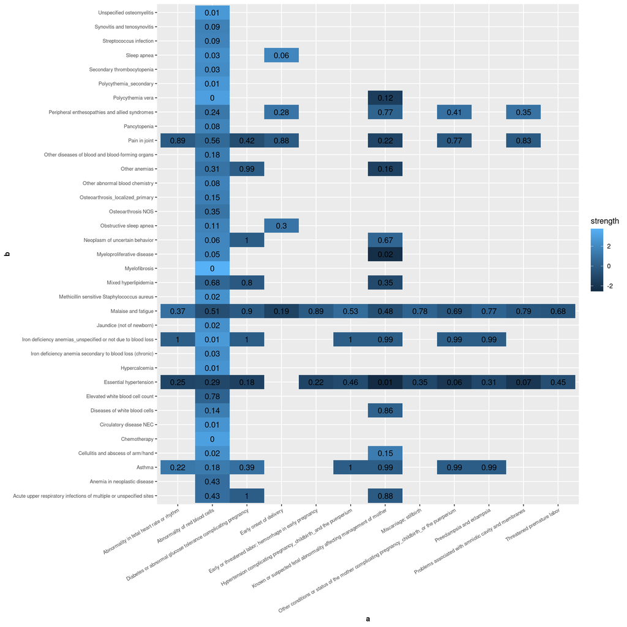

|  | JAK2 V617F non-carrier | JAK2 V617F carrier |
| --- | --- | --- |
| abnormal | 98 | 9 |
| normal | 91522 | 780 |

```
##
##  Fisher's Exact Test for Count Data
##
## data:  table(jak2_dat$abnormal_redbloodcell, jak2_dat$group)
## p-value = 3.923e-07
## alternative hypothesis: true odds ratio is not equal to 1
## 95 percent confidence interval:
##  0.04671762 0.20978607
## sample estimates:
## odds ratio
## 0.09283278
```

|  | JAK2 V617F non-carrier | JAK2 V617F carrier |
| --- | --- | --- |
| no subtype | 44592 | 309 |
| subtype | 47028 | 480 |

```
##
##  Fisher's Exact Test for Count Data
##
## data:  table(jak2_dat$subtype1, jak2_dat$group)
## p-value = 1.104e-07
## alternative hypothesis: true odds ratio is not equal to 1
## 95 percent confidence interval:
##  1.273250 1.705913
## sample estimates:
## odds ratio
##   1.472922
```

[interactive chart not shown]

| ID | Description | freq | phenotype | enrichmentScore | pvalue | p.adjust | qvalue |
| --- | --- | --- | --- | --- | --- | --- | --- |
| GO:0043228 | non-membrane-bounded organelle | 0.5000000 | Early or threatened labor; hemorrhage in early pregnancy | 1.0000000 | 0.0009296 | 0.0120851 | 0.0078284 |
| GO:0043228 | non-membrane-bounded organelle | 0.5000000 | Other conditions or status of the mother complicating pregnancy_childbirth_or the puerperium | 1.0000000 | 0.0009296 | 0.0120851 | 0.0078284 |
| GO:0043232 | intracellular non-membrane-bounded organelle | 0.5000000 | Early or threatened labor; hemorrhage in early pregnancy | 1.0000000 | 0.0009296 | 0.0120851 | 0.0078284 |
| GO:0043232 | intracellular non-membrane-bounded organelle | 0.5000000 | Other conditions or status of the mother complicating pregnancy_childbirth_or the puerperium | 1.0000000 | 0.0009296 | 0.0120851 | 0.0078284 |
| GO:0005654 | nucleoplasm | 0.5000000 | Early or threatened labor; hemorrhage in early pregnancy | 1.0000000 | 0.0075477 | 0.0490601 | 0.0317798 |
| GO:0005654 | nucleoplasm | 0.5000000 | Other conditions or status of the mother complicating pregnancy_childbirth_or the puerperium | 1.0000000 | 0.0075477 | 0.0490601 | 0.0317798 |
| GO:0031981 | nuclear lumen | 0.5000000 | Early or threatened labor; hemorrhage in early pregnancy | 1.0000000 | 0.0075477 | 0.0490601 | 0.0317798 |
| GO:0031981 | nuclear lumen | 0.5000000 | Other conditions or status of the mother complicating pregnancy_childbirth_or the puerperium | 1.0000000 | 0.0075477 | 0.0490601 | 0.0317798 |
| GO:0031982 | vesicle | 1.0000000 | Other conditions or status of the mother complicating pregnancy_childbirth_or the puerperium | 0.9978495 | 0.0339660 | 0.0883117 | 0.0572060 |
| GO:0031974 | membrane-enclosed lumen | 0.5000000 | Early or threatened labor; hemorrhage in early pregnancy | 1.0000000 | 0.0304897 | 0.0883117 | 0.0572060 |
| GO:0031974 | membrane-enclosed lumen | 0.5000000 | Other conditions or status of the mother complicating pregnancy_childbirth_or the puerperium | 1.0000000 | 0.0304897 | 0.0883117 | 0.0572060 |
| GO:0043233 | organelle lumen | 0.5000000 | Early or threatened labor; hemorrhage in early pregnancy | 1.0000000 | 0.0304897 | 0.0883117 | 0.0572060 |
| GO:0043233 | organelle lumen | 0.5000000 | Other conditions or status of the mother complicating pregnancy_childbirth_or the puerperium | 1.0000000 | 0.0304897 | 0.0883117 | 0.0572060 |
| GO:0070013 | intracellular organelle lumen | 0.5000000 | Early or threatened labor; hemorrhage in early pregnancy | 1.0000000 | 0.0304897 | 0.0883117 | 0.0572060 |
| GO:0070013 | intracellular organelle lumen | 0.5000000 | Other conditions or status of the mother complicating pregnancy_childbirth_or the puerperium | 1.0000000 | 0.0304897 | 0.0883117 | 0.0572060 |
| GO:0032991 | protein-containing complex | 1.0000000 | Other conditions or status of the mother complicating pregnancy_childbirth_or the puerperium | 0.9976690 | 0.0309690 | 0.0883117 | 0.0572060 |
| GO:0016020 | membrane | 1.0000000 | Other conditions or status of the mother complicating pregnancy_childbirth_or the puerperium | 0.9966997 | 0.0339660 | 0.0883117 | 0.0572060 |
| GO:0031090 | organelle membrane | 1.0000000 | Other conditions or status of the mother complicating pregnancy_childbirth_or the puerperium | 0.9978947 | 0.0612806 | 0.1327745 | 0.0860078 |
| GO:0005829 | cytosol | 0.5000000 | Early or threatened labor; hemorrhage in early pregnancy | 1.0000000 | 0.0612806 | 0.1327745 | 0.0860078 |
| GO:0005829 | cytosol | 0.5000000 | Other conditions or status of the mother complicating pregnancy_childbirth_or the puerperium | 1.0000000 | 0.0612806 | 0.1327745 | 0.0860078 |
| GO:0005634 | nucleus | 0.5000000 | Early or threatened labor; hemorrhage in early pregnancy | 1.0000000 | 0.1231663 | 0.2463327 | 0.1595677 |
| GO:0005634 | nucleus | 0.5000000 | Other conditions or status of the mother complicating pregnancy_childbirth_or the puerperium | 1.0000000 | 0.1231663 | 0.2463327 | 0.1595677 |
| GO:0012505 | endomembrane system | 1.0000000 | Other conditions or status of the mother complicating pregnancy_childbirth_or the puerperium | 0.9977427 | 0.2475491 | 0.4022673 | 0.2605780 |
| GO:0016021 | integral component of membrane | 1.0000000 | Other conditions or status of the mother complicating pregnancy_childbirth_or the puerperium | 0.9976798 | 0.2475491 | 0.4022673 | 0.2605780 |
| GO:0031224 | intrinsic component of membrane | 1.0000000 | Other conditions or status of the mother complicating pregnancy_childbirth_or the puerperium | 0.9976526 | 0.2475491 | 0.4022673 | 0.2605780 |
| GO:0005615 | extracellular space | 1.0000000 | Other conditions or status of the mother complicating pregnancy_childbirth_or the puerperium | 0.9916667 | 0.3236763 | 0.4950344 | 0.3206700 |
| GO:0005576 | extracellular region | 1.0000000 | Other conditions or status of the mother complicating pregnancy_childbirth_or the puerperium | 0.9912854 | 0.3546454 | 0.5122655 | 0.3318319 |
| GO:0005622 | intracellular anatomical structure | 0.3333333 | Early or threatened labor; hemorrhage in early pregnancy | 1.0000000 | 0.4975431 | 0.5174448 | 0.3351869 |
| GO:0005622 | intracellular anatomical structure | 0.6666667 | Other conditions or status of the mother complicating pregnancy_childbirth_or the puerperium | 1.0000000 | 0.4975431 | 0.5174448 | 0.3351869 |
| GO:0043226 | organelle | 0.3333333 | Early or threatened labor; hemorrhage in early pregnancy | 1.0000000 | 0.4975431 | 0.5174448 | 0.3351869 |

[output cut: 771 more lines]

### Clusters underlying biological mechanisms

- Basically, you could download the subgroup table for each disease cluster and upload the file into Phe-OmicsMIME to delve into the underlying biological mechanisms
- Here is the link to the Phe-OmicsMIME

[Phe-OmicsMIME](https://prod.tbilab.org/content/99395bec-6a59-4526-b1cf-e973e7746261)